# 2.2.25

## 2.2.25

A list of college wrestling champions for the years 1981dash 2005 is given in the table. Each college has been associated with a particular letter. Use this data to complete parts (a) through (d).

**(a) Determine a frequency distribution.**

First, we need to import the data from Excel. (For simplicity, this imports mannual by hand, we can get the same result by importing dataset from Excel)

```r
data <- c("C", "B", "E", "B", "A", "B", "C", "A", "B", "C", "C", "B", "E", "C", "D", "B", "C", "A", "C", "A", "C", "B", "E", "A", "A")
data
```

```
##  [1] "C" "B" "E" "B" "A" "B" "C" "A" "B" "C" "C" "B" "E" "C" "D" "B" "C" "A" "C"
## [20] "A" "C" "B" "E" "A" "A"
```

We can get the frequency by using table() command

```r
table(data)
```

```
## data
## A B C D E
## 6 7 8 1 3
```

To display frenquency table in column format use cbind() command

```r
cbind(table(data))
```

```
##   [,1]
## A    6
## B    7
## C    8
## D    1
## E    3
```

**(b) Obtain a relative-frequency distribution.**

To display relative frenquency table in column format use cbind() command

```r
cbind(table(data)/length(data))
```

```
##   [,1]
## A 0.24
## B 0.28
## C 0.32
## D 0.04
## E 0.12
```

To display the result appropriate to 5 decimal places use print() command

In this case, we have nice results so it does not show the difference.

```r
print(table(data)/length(data), 5)
```

```
## data
##    A    B    C    D    E
## 0.24 0.28 0.32 0.04 0.12
```

**(c) Draw a pie chart. Choose the correct chart below.**

Store relative-frequency table in a variable x

```r
x <- table(data)/length(data)
```

Display pie chart using pie() command

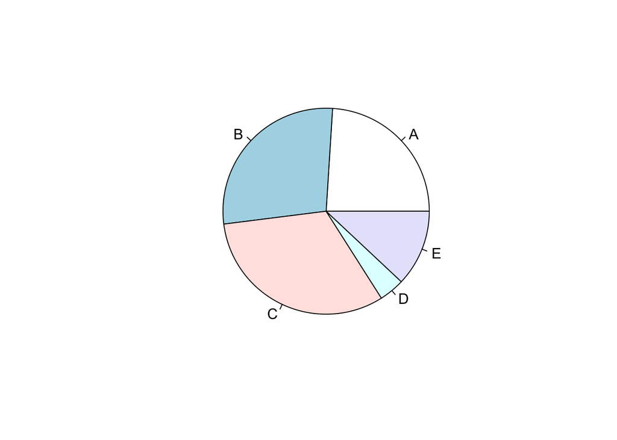

```r
pie(x)
```

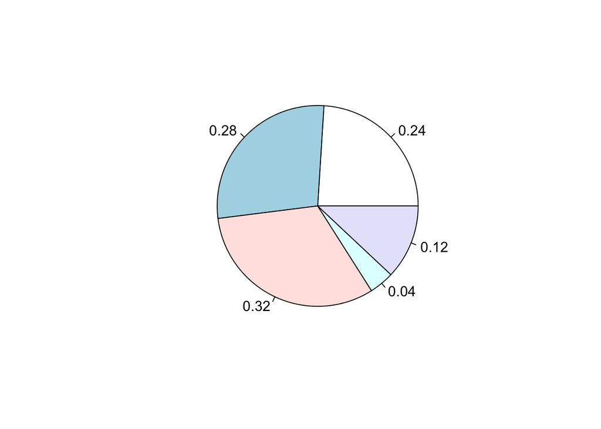

```r
pie(x, labels = x)
```

**(d) Construct a bar chart. Choose the correct chart below.**

Display bar chart using barplot() command

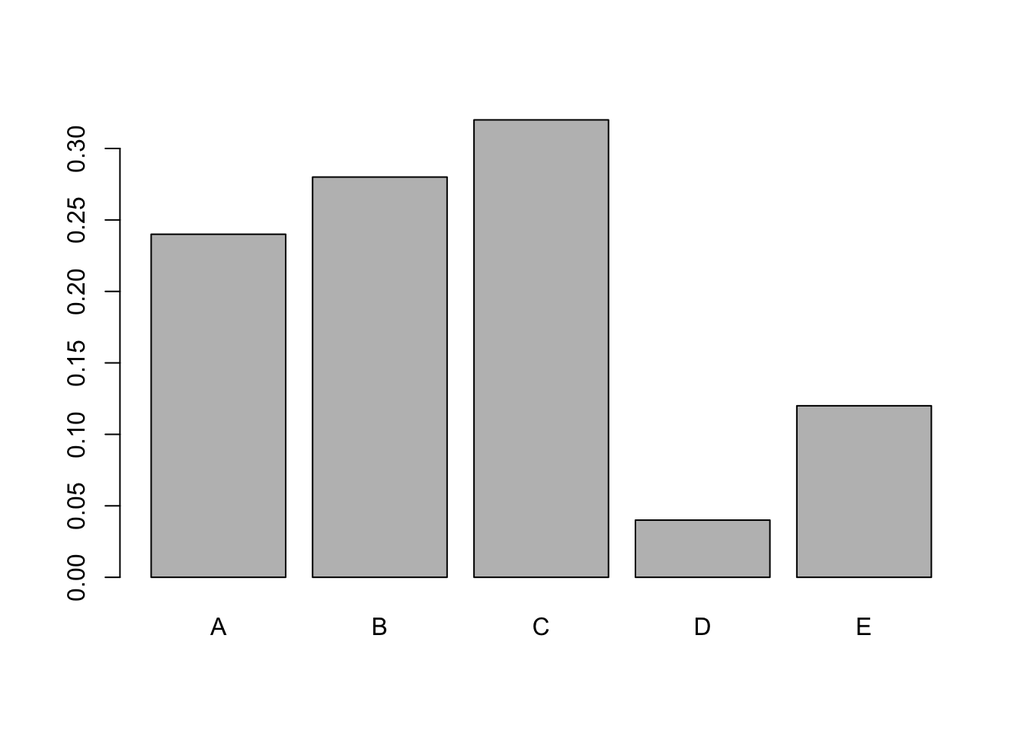

```r
barplot(x)
```

**Hope that helps!**